# E2Q1 v4 Strike

```python
#Importing libraries
import pandas as pd
from numpy import *
import numpy as np
```

```python
#function for geometric mean
def g_mean(x):
    a = np.log(x)
    return np.exp(a.mean())
```

```python
# Function for simualation: Closed-Form GBM, Euler-Murayama, Milstein
def simulate_path(s0, mu, sigma, horizon, timesteps, n_sims,scheme):

    # set the random seed for reproducibility
    random.seed(1)

    # read parameters
    S0 = s0                 # initial spot price
    r = mu                  # mu = rf in risk neutral framework
    T = horizon             # time horizon
    t = timesteps           # number of time steps
    n = n_sims              # number of simulation

    # define dt
    dt = T/t                # length of time interval

    # simulate 'n' asset price path with 't' timesteps
    S = zeros((t,n))
    S[0] = S0


    # Euler-Murayama scheme
    if scheme=='EM':
        for i in range(0, t-1):
            w = random.standard_normal(n)
            S[i+1] = S[i] * (1 + r*dt + sigma*sqrt(dt)*w)

    # Milstein scheme
    elif scheme=='Mils':
        for i in range(0, t-1):
            w = random.standard_normal(n)
            #S[i+1] = S[i] * (1 + r*dt + sigma*sqrt(dt)*w)
            S[i+1] = S[i] *(1 + r*dt + sigma*sqrt(dt)*w) + (0.5*sigma*sigma*(w*w-1)*dt)

    # Geometric Brownian Motion
    elif scheme=='GBM':
        for i in range(0, t-1):
            w = random.standard_normal(n)
            S[i+1] = S[i] * e**((r-0.5*sigma*sigma)*dt+(sigma*w*sqrt(dt)))

    return S
```

```python
def asian_avg(df, n, avg, samp ):
    """"
     This function performs discrete or continuous averaging on dataframe by either arithmetic or geometric mean.
     n = number of observation for every simulation.
         if samp is "cont" then n is obsolete regardless of input (requires a dummy input at least).
     avg: arithmetic -"arith" or geometric- "geo".
     samp: discrete - "disc" or continuous - "cont".
    """
    #discrete sampling
    if samp == 'disc':
        #sampling period
        period  = int(np.round(df.shape[0]/(n)))

        #create a new df containing only values of observed period
        df_p= df.iloc[period::period, :]

        if avg== 'arith':
            avg_df = df_p.mean(axis=0)
        elif avg== 'geo':
            avg_df = g_mean(df_p)

    #continous sampling
    elif samp == 'cont':
        if avg== 'arith':
            avg_df = df.mean(axis=0)
        elif avg== 'geo':
            avg_df = g_mean(df)

    return avg_df
```

```python
def asian_payoff(arr, cp , K, avg, samp, avgSorK, n):
     """
        Purpose: The  function will perform various asian variant payoff upon generated spot path based on user input
        (i) arr: array containing randomized stock path generated with either Euler, Milstein or GBM scheme
        (ii) callput : call or put
        (iii) K, Strike price: will be overriden by the mean if fixed price is specified under avgSorK
        (iv)  avg: averaging method. arithmetic -"arith" or geometric- "geo"
        (v)   samp: sampling method. continuous- "cont" or discrete- "disc"
        (vi)  avgSorK: avgS means fixed strike,
                       avgK means the average price will form the strike
        (vii)  n:  number of observation for every simulation.
                 if samp is "cont" then n is obsolete regardless of input (at least a random number).
    """
    df_arr =  pd.DataFrame(arr)
    asian = asian_avg(df_arr, n, avg, samp)

    if cp== 'call':
        if avgSorK == 'avgS':   #Fixed Strike
            payoff = mean(maximum(0, asian - K))
        if avgSorK == 'avgK':   #Fixed Price
            payoff =  mean(maximum(0, arr[-1]-asian ))

    elif cp== 'put':
        if avgSorK == 'avgS':   #Fixed Strike
            payoff = mean(maximum(0, K-asian))
        if avgSorK == 'avgK':   #Fixed Price
            payoff =  mean(maximum(0, asian- arr[-1]))

    return payoff
```

```python
def test_sim( r, sigma,T, timesteps, n_sims, K=100): #Stike argument is optional

    # (s0, mu, sigma, time horizon, timesteps, n_sims,scheme)
    SEM = simulate_path(100,r,sigma,T,timesteps,n_sims,'EM') #Euler-Maruyama scheme
    SGBM= simulate_path(100,r,sigma,T,timesteps,n_sims,'GBM') #Geometric Brownian Motion
    SMils = simulate_path(100,r,sigma,T,timesteps,n_sims,'Mils') #Milstein scheme

    """
    #Naming convention for the Asian variant
    (i) Call or Put
    (ii) Scheme: Euler, EM/ Milstein, Mils/ Geometric Brownian Motion, GBM
    (iii)Averaging Method: Arithmetic, Arith/Geometric, Geo
    (iv) Sampling: Continuous, Cont/ Discrete, Disc
    (v) Strike type: Fixed Prices, FP/ Fixed Strike, FS

    Name: (i)_(ii)_(iii)_(iv)_(v)
    """
    # Continuous sampling with Arithmetic mean
    A1= Call_EM_A_C_FS= exp(-r*T) *asian_payoff(SEM, 'call', K, 'arith', 'cont', 'avgS', 12)
    A2 = Call_GBM_A_C_FS= exp(-r*T) *asian_payoff(SGBM, 'call', K, 'arith', 'cont', 'avgS', 12)
    A3 = Call_Mils_A_C_FS= exp(-r*T) *asian_payoff(SMils, 'call', K, 'arith', 'cont', 'avgS', 12)

    A4=Put_EM_A_C_FS= exp(-r*T) *asian_payoff(SEM, 'put', K, 'arith', 'cont', 'avgS', 12)
    A5=Put_GBM_A_C_FS= exp(-r*T) *asian_payoff(SGBM, 'put', K, 'arith', 'cont', 'avgS', 12)
    A6=Put_Mils_A_C_FS= exp(-r*T) *asian_payoff(SMils, 'put', K, 'arith', 'cont', 'avgS', 12)

    A7=Call_EM_A_C_FP= exp(-r*T) *asian_payoff(SEM, 'call', K, 'arith', 'cont', 'avgK', 12)
    A8=Call_GBM_A_C_FP= exp(-r*T) *asian_payoff(SGBM, 'call', K, 'arith', 'cont', 'avgK', 12)
    A9=Call_Mils_A_C_FP= exp(-r*T) *asian_payoff(SMils, 'call', K, 'arith', 'cont', 'avgK', 12)

    A10= Put_EM_A_C_FP= exp(-r*T) *asian_payoff(SEM, 'put', K, 'arith', 'cont', 'avgK', 12)
    A11= Put_GBM_A_C_FP= exp(-r*T) *asian_payoff(SGBM, 'put', K, 'arith', 'cont', 'avgK', 12)
    A12= Put_Mils_A_C_FP= exp(-r*T) *asian_payoff(SMils, 'put', K, 'arith', 'cont', 'avgK', 12)

    # Discrete sampling with Arithmetic mean
    A1d= Call_EM_A_D_FS= exp(-r*T) *asian_payoff(SEM, 'call', K, 'arith', 'disc', 'avgS', 12)
    A2d= Call_GBM_A_D_FS= exp(-r*T) *asian_payoff(SGBM, 'call', K, 'arith', 'disc', 'avgS', 12)
    A3d= Call_Mils_A_D_FS= exp(-r*T) *asian_payoff(SMils, 'call', K, 'arith', 'disc', 'avgS', 12)

    A4d=Put_EM_A_D_FS= exp(-r*T) *asian_payoff(SEM, 'put', K, 'arith', 'disc', 'avgS', 12)
    A5d=Put_GBM_A_D_FS= exp(-r*T) *asian_payoff(SGBM, 'put', K, 'arith', 'disc', 'avgS', 12)
    A6d=Put_Mils_A_D_FS= exp(-r*T) *asian_payoff(SMils, 'put', K, 'arith', 'disc', 'avgS', 12)

    A7d=Call_EM_A_D_FP= exp(-r*T) *asian_payoff(SEM, 'call', K, 'arith', 'disc', 'avgK', 12)
    A8d=Call_GBM_A_D_FP= exp(-r*T) *asian_payoff(SGBM, 'call', K, 'arith', 'disc', 'avgK', 12)
    A9d=Call_Mils_A_D_FP= exp(-r*T) *asian_payoff(SMils, 'call', K, 'arith', 'disc', 'avgK', 12)

    A10d= Put_EM_A_D_FP= exp(-r*T) *asian_payoff(SEM, 'put', K, 'arith', 'disc', 'avgK', 12)
    A11d= Put_GBM_A_D_FP= exp(-r*T) *asian_payoff(SGBM, 'put', K, 'arith', 'disc', 'avgK', 12)
    A12d= Put_Mils_A_D_FP= exp(-r*T) *asian_payoff(SMils, 'put', K, 'arith', 'disc', 'avgK', 12)


    Acont = pd.DataFrame({"Ins Code":['A1','A3','A4','A6','A7','A9','A10','A12'],
                          "Ins Name": ['Call_EM_A_C_FS','Call_Mils_A_C_FS','Put_EM_A_C_FS','Put_Mils_A_C_FS','Call_EM_A_C_FP',
                                   'Call_Mils_A_C_FP','Put_EM_A_C_FP','Put_Mils_A_C_FP'],
                         "Rel Diff to GBM Price, %":[abs(A1/A2-1),abs(A3/A2-1),abs(A4/A5-1),abs(A6/A5-1),abs(A7/A8-1),
                                  abs(A9/A8-1),abs(A10/A11-1),abs(A12/A11-1)]})

    Acont['Rel Diff to GBM Price, %'] = pd.Series(["{0:.3f}%".format(val*100) for val in Acont['Rel Diff to GBM Price, %']], index = Acont.index)


    Adisc = pd.DataFrame({"Ins Code":['A1d','A3d','A4d','A6d','A7d','A9d','A10d','A12d'],
                          "Ins Name": ['Call_EM_A_D_FS','Call_Mils_A_D_FS','Put_EM_A_D_FS','Put_Mils_A_D_FS','Call_EM_A_D_FP',
                                   'Call_Mils_A_D_FP','Put_EM_A_D_FP','Put_Mils_A_D_FP'],
                         "Rel Diff to GBM Price, %":[abs(A1d/A2d-1),abs(A3d/A2d-1),abs(A4d/A5d-1),abs(A6d/A5d-1),abs(A7d/A8d-1),
                                  abs(A9d/A8d-1),abs(A10d/A11d-1),abs(A12d/A11d-1)]})
    Adisc['Rel Diff to GBM Price, %'] = pd.Series(["{0:.3f}%".format(val*100) for val in Adisc['Rel Diff to GBM Price, %']], index = Adisc.index)


    AConsol =   Acont.compare(Adisc,keep_shape=True, keep_equal=True)

    #  Continuous sampling with Geometric Asian
    G1= Call_EM_G_C_FS= exp(-r*T) *asian_payoff(SEM, 'call', K, 'geo', 'cont', 'avgS', 12)
    G2= Call_GBM_G_C_FS= exp(-r*T) *asian_payoff(SGBM, 'call', K, 'geo', 'cont', 'avgS', 12)
    G3=Call_Mils_G_C_FS= exp(-r*T) *asian_payoff(SMils, 'call', K, 'geo', 'cont', 'avgS', 12)

    G4=Put_EM_G_C_FS= exp(-r*T) *asian_payoff(SEM, 'put', K, 'geo', 'cont', 'avgS', 12)
    G5=Put_GBM_G_C_FS= exp(-r*T) *asian_payoff(SGBM, 'put', K, 'geo', 'cont', 'avgS', 12)
    G6=Put_Mils_G_C_FS= exp(-r*T) *asian_payoff(SMils, 'put', K, 'geo', 'cont', 'avgS', 12)

    G7=Call_EM_G_C_FP= exp(-r*T) *asian_payoff(SEM, 'call', K, 'geo', 'cont', 'avgK', 12)
    G8=Call_GBM_G_C_FP= exp(-r*T) *asian_payoff(SGBM, 'call', K, 'geo', 'cont', 'avgK', 12)
    G9=Call_Mils_G_C_FP= exp(-r*T) *asian_payoff(SMils, 'call', K, 'geo', 'cont', 'avgK', 12)

    G10=Put_EM_G_C_FP= exp(-r*T) *asian_payoff(SEM, 'put', K, 'geo', 'cont', 'avgK', 12)
    G11=Put_GBM_G_C_FP= exp(-r*T) *asian_payoff(SGBM, 'put', K, 'geo', 'cont', 'avgK', 12)
    G12= Put_Mils_G_C_FP= exp(-r*T) *asian_payoff(SMils, 'put', K, 'geo', 'cont', 'avgK', 12)

    #  Discrete sampling with Geometric Asian
    G1d= Call_EM_G_D_FS= exp(-r*T) *asian_payoff(SEM, 'call', K, 'geo', 'cont', 'avgS', 12)
    G2d= Call_GBM_G_D_FS= exp(-r*T) *asian_payoff(SGBM, 'call', K, 'geo', 'cont', 'avgS', 12)
    G3d=Call_Mils_G_D_FS= exp(-r*T) *asian_payoff(SMils, 'call', K, 'geo', 'cont', 'avgS', 12)

    G4d=Put_EM_G_D_FS= exp(-r*T) *asian_payoff(SEM, 'put', K, 'geo', 'cont', 'avgS', 12)
    G5d=Put_GBM_G_D_FS= exp(-r*T) *asian_payoff(SGBM, 'put', K, 'geo', 'cont', 'avgS', 12)
    G6d=Put_Mils_G_D_FS= exp(-r*T) *asian_payoff(SMils, 'put', K, 'geo', 'cont', 'avgS', 12)

    G7d=Call_EM_G_D_FP= exp(-r*T) *asian_payoff(SEM, 'call', K, 'geo', 'cont', 'avgK', 12)
    G8d=Call_GBM_G_D_FP= exp(-r*T) *asian_payoff(SGBM, 'call', K, 'geo', 'cont', 'avgK', 12)
    G9d=Call_Mils_G_D_FP= exp(-r*T) *asian_payoff(SMils, 'call', K, 'geo', 'cont', 'avgK', 12)

    G10d=Put_EM_G_D_FP= exp(-r*T) *asian_payoff(SEM, 'put', K, 'geo', 'cont', 'avgK', 12)
    G11d=Put_GBM_G_D_FP= exp(-r*T) *asian_payoff(SGBM, 'put', K, 'geo', 'cont', 'avgK', 12)
    G12d= Put_Mils_G_D_FP= exp(-r*T) *asian_payoff(SMils, 'put', K, 'geo', 'cont', 'avgK', 12)


    Gcont = pd.DataFrame({"Ins Code":['G1','G3','G4','G6','G7','G9','G10','G12'],
                          "Ins Name": ['Call_EM_G_C_FS','Call_Mils_G_C_FS','Put_EM_G_C_FS', 'Put_Mils_G_C_FS', 'Call_EM_G_C_FP',
                                  'Call_Mils_G_C_FP','Put_EM_G_C_FP','Put_Mils_G_C_FP'],
                         "Rel Diff to GBM Price, %":[abs(G1/G2-1),abs(G3/G2-1),abs(G4/G5-1),abs(G6/G5-1),abs(G7/G8-1),
                                  abs(G9/G8-1),abs(G10/G11-1),abs(G12/G11-1)]})

    Gcont['Rel Diff to GBM Price, %'] = pd.Series(["{0:.3f}%".format(val*100) for val in Gcont['Rel Diff to GBM Price, %']], index = Gcont.index)


    Gdisc = pd.DataFrame({"Ins Code":['G1d','G3d','G4d','G6d','G7d','G9d','G10d','G12d'],
                          "Ins Name": ['Call_EM_G_D_FS','Call_Mils_G_D_FS','Put_EM_G_D_FS','Put_Mils_G_D_FS','Call_EM_G_D_FP',
                                   'Call_Mils_G_D_FP','Put_EM_G_D_FP','Put_Mils_G_D_FP'],
                         "Rel Diff to GBM Price, %":[abs(G1d/G2d-1),abs(G3d/G2d-1),abs(G4d/G5d-1),abs(G6d/G5d-1),abs(G7d/G8d-1),
                                  abs(G9d/G8d-1),abs(G10d/G11d-1),abs(G12d/G11d-1)]})

    Gdisc['Rel Diff to GBM Price, %'] = pd.Series(["{0:.3f}%".format(val*100) for val in Gdisc['Rel Diff to GBM Price, %']], index = Gdisc.index)

    Gcont

    GConsol =   Gcont.compare(Gdisc,keep_shape=True, keep_equal=True)
    TotalConsol = AConsol.compare(GConsol,keep_shape=True, keep_equal=True)

    return TotalConsol
```

**READ HERE: HOW TO READ THE TABLES**

The table is presented in 2 groups with columns of 4s. Every column corresponds to the subsequent groups' name and value.

The point of such presentation is to have an apple-to-apple relative comparison between EM (relative to GBM) and Milstein (relative to GBM).

```
Naming convention for each instrument is as follows
(i) Call or Put
(ii) Scheme: Euler, EM/ Milstein, Mils/ Geometric Brownian Motion, GBM
(iii)Averaging Method: Arithmetic, A/Geometric, G
(iv) Sampling: Continuous, C/ Discrete, D
(v) Strike type: Fixed Prices, FP/ Fixed Strike, FS

Name: (i)_(ii)_(iii)_(iv)_(v), Example: Call_EM_A_C_FS
```

Instrument name with GBM will not be present as data presented will be relative difference between the schemes against GBM (example Call_GBM_A_C_FS will not be present).

Example illustrated below:

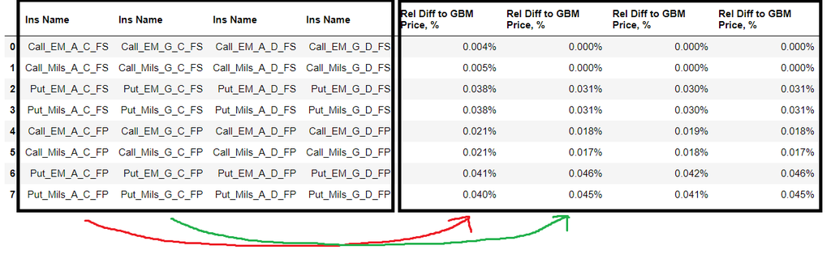

```python
# Relative Diff to GBM Price,% Base Case 5k simulations
#The result will also serve as a base case for comparison with other cases with varied parameters

# r=0.05, sigma= 0.2, time horizon = 1 year,timesteps =252 , n_sims =5000)
t1 =test_sim (0.05, 0.2 ,1 , 252, 5000)

#row reorganization to allow for EM vs Milstein
t1=t1.iloc[[0,1,2,3,4,5,6,7]]

t1 = t1.droplevel(2, axis=1).droplevel(1, axis=1).drop(['Ins Code'], axis=1)

t1
```

|  | Ins Name | Ins Name | Ins Name | Ins Name | Rel Diff to GBM Price, % | Rel Diff to GBM Price, % | Rel Diff to GBM Price, % | Rel Diff to GBM Price, % |
| --- | --- | --- | --- | --- | --- | --- | --- | --- |
| 0 | Call_EM_A_C_FS | Call_EM_G_C_FS | Call_EM_A_D_FS | Call_EM_G_D_FS | 0.004% | 0.000% | 0.000% | 0.000% |
| 1 | Call_Mils_A_C_FS | Call_Mils_G_C_FS | Call_Mils_A_D_FS | Call_Mils_G_D_FS | 0.005% | 0.000% | 0.000% | 0.000% |
| 2 | Put_EM_A_C_FS | Put_EM_G_C_FS | Put_EM_A_D_FS | Put_EM_G_D_FS | 0.038% | 0.031% | 0.030% | 0.031% |
| 3 | Put_Mils_A_C_FS | Put_Mils_G_C_FS | Put_Mils_A_D_FS | Put_Mils_G_D_FS | 0.038% | 0.031% | 0.030% | 0.031% |
| 4 | Call_EM_A_C_FP | Call_EM_G_C_FP | Call_EM_A_D_FP | Call_EM_G_D_FP | 0.021% | 0.018% | 0.019% | 0.018% |
| 5 | Call_Mils_A_C_FP | Call_Mils_G_C_FP | Call_Mils_A_D_FP | Call_Mils_G_D_FP | 0.021% | 0.017% | 0.018% | 0.017% |
| 6 | Put_EM_A_C_FP | Put_EM_G_C_FP | Put_EM_A_D_FP | Put_EM_G_D_FP | 0.041% | 0.046% | 0.042% | 0.046% |
| 7 | Put_Mils_A_C_FP | Put_Mils_G_C_FP | Put_Mils_A_D_FP | Put_Mils_G_D_FP | 0.040% | 0.045% | 0.041% | 0.045% |

**Observation for t1:**

Generally, for the base case with 5k simulations, the accuracy betwen Euler-Maruyama ("EM") and Milstein scheme is very close with immaterial difference, with the following characteristics:

(i) EM has slightly better accuracy for Call_EM_A_C_FS

(ii) Milstein has slightly better accuracy for Call_Mils_G_C_FP, Call_Mils_G_D_FP, Put_Mils_A_C_FP, Put_Mils_G_C_FP, Put_Mils_A_D_FP, Put_Mils_G_D_FP

(iii) Calls have relatively better accuracy than its put counterpart of the same variant and scheme.

```python
#Relative Diff to GBM Price,% with 10k simulations "
t2 =test_sim (0.05, 0.2 ,1 , 252, 10000)
t2=t2.iloc[[0,1,2,3,4,5,6,7]]

t2 = t2.droplevel(2, axis=1).droplevel(1, axis=1).drop(['Ins Code'], axis=1)

tmp2 = pd.concat([t2, t1], keys=['10k', 'Base'])

tmp2.iloc[[0,8,1,9,2,10,3,11,4,12,5,13,6,14,7,15]].style.set_caption("Relative Diff to GBM Price,% with 10k simulations ")
```

Relative Diff to GBM Price,% with 10k simulations

|  |  | Ins Name | Ins Name | Ins Name | Ins Name | Rel Diff to GBM Price, % | Rel Diff to GBM Price, % | Rel Diff to GBM Price, % | Rel Diff to GBM Price, % |
| --- | --- | --- | --- | --- | --- | --- | --- | --- | --- |
| 10k | 0 | Call_EM_A_C_FS | Call_EM_G_C_FS | Call_EM_A_D_FS | Call_EM_G_D_FS | 0.015% | 0.016% | 0.013% | 0.016% |
| Base | 0 | Call_EM_A_C_FS | Call_EM_G_C_FS | Call_EM_A_D_FS | Call_EM_G_D_FS | 0.004% | 0.000% | 0.000% | 0.000% |
| 10k | 1 | Call_Mils_A_C_FS | Call_Mils_G_C_FS | Call_Mils_A_D_FS | Call_Mils_G_D_FS | 0.015% | 0.016% | 0.012% | 0.016% |
| Base | 1 | Call_Mils_A_C_FS | Call_Mils_G_C_FS | Call_Mils_A_D_FS | Call_Mils_G_D_FS | 0.005% | 0.000% | 0.000% | 0.000% |
| 10k | 2 | Put_EM_A_C_FS | Put_EM_G_C_FS | Put_EM_A_D_FS | Put_EM_G_D_FS | 0.004% | 0.004% | 0.009% | 0.004% |
| Base | 2 | Put_EM_A_C_FS | Put_EM_G_C_FS | Put_EM_A_D_FS | Put_EM_G_D_FS | 0.038% | 0.031% | 0.030% | 0.031% |
| 10k | 3 | Put_Mils_A_C_FS | Put_Mils_G_C_FS | Put_Mils_A_D_FS | Put_Mils_G_D_FS | 0.004% | 0.004% | 0.009% | 0.004% |
| Base | 3 | Put_Mils_A_C_FS | Put_Mils_G_C_FS | Put_Mils_A_D_FS | Put_Mils_G_D_FS | 0.038% | 0.031% | 0.030% | 0.031% |
| 10k | 4 | Call_EM_A_C_FP | Call_EM_G_C_FP | Call_EM_A_D_FP | Call_EM_G_D_FP | 0.032% | 0.030% | 0.034% | 0.030% |
| Base | 4 | Call_EM_A_C_FP | Call_EM_G_C_FP | Call_EM_A_D_FP | Call_EM_G_D_FP | 0.021% | 0.018% | 0.019% | 0.018% |
| 10k | 5 | Call_Mils_A_C_FP | Call_Mils_G_C_FP | Call_Mils_A_D_FP | Call_Mils_G_D_FP | 0.032% | 0.030% | 0.033% | 0.030% |
| Base | 5 | Call_Mils_A_C_FP | Call_Mils_G_C_FP | Call_Mils_A_D_FP | Call_Mils_G_D_FP | 0.021% | 0.017% | 0.018% | 0.017% |
| 10k | 6 | Put_EM_A_C_FP | Put_EM_G_C_FP | Put_EM_A_D_FP | Put_EM_G_D_FP | 0.025% | 0.025% | 0.028% | 0.025% |
| Base | 6 | Put_EM_A_C_FP | Put_EM_G_C_FP | Put_EM_A_D_FP | Put_EM_G_D_FP | 0.041% | 0.046% | 0.042% | 0.046% |
| 10k | 7 | Put_Mils_A_C_FP | Put_Mils_G_C_FP | Put_Mils_A_D_FP | Put_Mils_G_D_FP | 0.025% | 0.024% | 0.028% | 0.024% |
| Base | 7 | Put_Mils_A_C_FP | Put_Mils_G_C_FP | Put_Mils_A_D_FP | Put_Mils_G_D_FP | 0.040% | 0.045% | 0.041% | 0.045% |

**Observation for t2:**

With increased number of simulations from 5k to 10k,

(i) Accuracy for Calls declined (showing higher relative difference) across variants and schemes.

(ii) Accuracy for Puts improved across variants and schemes.

(iii) Relative difference (against GBM) between EM and Milstein scheme matches up closer across all variants. This implies a convergence in price between both schemes.

```
  Example: Put_EM_A_C_FP, 0.025% vs  Put_Mils_A_C_FP, 0.025%
```

(iv) Puts have relatively better accuracy than its call counterpart of the same variant and scheme.

```python
#"Relative Diff to GBM Price,% with 60% Volatility "
t3 =test_sim (0.05, 0.6 ,1 , 252, 5000)
t3=t3.iloc[[0,1,2,3,4,5,6,7]]
t3 = t3.droplevel(2, axis=1).droplevel(1, axis=1).drop(['Ins Code'], axis=1)

tmp3 = pd.concat([t3, t1], keys=['60%', 'Base'])
tmp3.iloc[[0,8,1,9,2,10,3,11,4,12,5,13,6,14,7,15]].style.set_caption("Relative Diff to GBM Price,% with 60% Volatility ")
```

Relative Diff to GBM Price,% with 60% Volatility

|  |  | Ins Name | Ins Name | Ins Name | Ins Name | Rel Diff to GBM Price, % | Rel Diff to GBM Price, % | Rel Diff to GBM Price, % | Rel Diff to GBM Price, % |
| --- | --- | --- | --- | --- | --- | --- | --- | --- | --- |
| 60% | 0 | Call_EM_A_C_FS | Call_EM_G_C_FS | Call_EM_A_D_FS | Call_EM_G_D_FS | 0.054% | 0.054% | 0.055% | 0.054% |
| Base | 0 | Call_EM_A_C_FS | Call_EM_G_C_FS | Call_EM_A_D_FS | Call_EM_G_D_FS | 0.004% | 0.000% | 0.000% | 0.000% |
| 60% | 1 | Call_Mils_A_C_FS | Call_Mils_G_C_FS | Call_Mils_A_D_FS | Call_Mils_G_D_FS | 0.053% | 0.053% | 0.054% | 0.053% |
| Base | 1 | Call_Mils_A_C_FS | Call_Mils_G_C_FS | Call_Mils_A_D_FS | Call_Mils_G_D_FS | 0.005% | 0.000% | 0.000% | 0.000% |
| 60% | 2 | Put_EM_A_C_FS | Put_EM_G_C_FS | Put_EM_A_D_FS | Put_EM_G_D_FS | 0.016% | 0.008% | 0.020% | 0.008% |
| Base | 2 | Put_EM_A_C_FS | Put_EM_G_C_FS | Put_EM_A_D_FS | Put_EM_G_D_FS | 0.038% | 0.031% | 0.030% | 0.031% |
| 60% | 3 | Put_Mils_A_C_FS | Put_Mils_G_C_FS | Put_Mils_A_D_FS | Put_Mils_G_D_FS | 0.016% | 0.008% | 0.020% | 0.008% |
| Base | 3 | Put_Mils_A_C_FS | Put_Mils_G_C_FS | Put_Mils_A_D_FS | Put_Mils_G_D_FS | 0.038% | 0.031% | 0.030% | 0.031% |
| 60% | 4 | Call_EM_A_C_FP | Call_EM_G_C_FP | Call_EM_A_D_FP | Call_EM_G_D_FP | 0.226% | 0.183% | 0.211% | 0.183% |
| Base | 4 | Call_EM_A_C_FP | Call_EM_G_C_FP | Call_EM_A_D_FP | Call_EM_G_D_FP | 0.021% | 0.018% | 0.019% | 0.018% |
| 60% | 5 | Call_Mils_A_C_FP | Call_Mils_G_C_FP | Call_Mils_A_D_FP | Call_Mils_G_D_FP | 0.225% | 0.182% | 0.210% | 0.182% |
| Base | 5 | Call_Mils_A_C_FP | Call_Mils_G_C_FP | Call_Mils_A_D_FP | Call_Mils_G_D_FP | 0.021% | 0.017% | 0.018% | 0.017% |
| 60% | 6 | Put_EM_A_C_FP | Put_EM_G_C_FP | Put_EM_A_D_FP | Put_EM_G_D_FP | 0.034% | 0.030% | 0.027% | 0.030% |
| Base | 6 | Put_EM_A_C_FP | Put_EM_G_C_FP | Put_EM_A_D_FP | Put_EM_G_D_FP | 0.041% | 0.046% | 0.042% | 0.046% |
| 60% | 7 | Put_Mils_A_C_FP | Put_Mils_G_C_FP | Put_Mils_A_D_FP | Put_Mils_G_D_FP | 0.034% | 0.029% | 0.027% | 0.029% |
| Base | 7 | Put_Mils_A_C_FP | Put_Mils_G_C_FP | Put_Mils_A_D_FP | Put_Mils_G_D_FP | 0.040% | 0.045% | 0.041% | 0.045% |

**Observation for t3:**

With increased volatility from 20% to 60%,

(i) Accuracy for Calls declined across variants and schemes

(ii) Accuracy for Puts improved slightly across variants and schemes

(iii) Relative difference (against GBM) between EM and Milstein converges across all variants. This implies a possible convergence in price between both schemes.

```
  Example: Put_EM_A_C_FP, 0.034% vs  Put_Mils_A_C_FP, 0.034%
```

```python
# 500 timestpes, time to expiry - 2years, 504 steps
t4 =test_sim (0.05, 0.6 , 2 , 504, 5000)
t4.iloc[[0,1,2,3,4,5,6,7]]
t4 = t4.droplevel(2, axis=1).droplevel(1, axis=1).drop(['Ins Code'], axis=1)

tmp4 = pd.concat([t4, t1], keys=['T=2', 'Base'])
tmp4.iloc[[0,8,1,9,2,10,3,11,4,12,5,13,6,14,7,15]].style.set_caption("Relative Diff to GBM Price,% with T= 2 , 504 timestpes ")
```

Relative Diff to GBM Price,% with T= 2 , 504 timestpes

|  |  | Ins Name | Ins Name | Ins Name | Ins Name | Rel Diff to GBM Price, % | Rel Diff to GBM Price, % | Rel Diff to GBM Price, % | Rel Diff to GBM Price, % |
| --- | --- | --- | --- | --- | --- | --- | --- | --- | --- |
| T=2 | 0 | Call_EM_A_C_FS | Call_EM_G_C_FS | Call_EM_A_D_FS | Call_EM_G_D_FS | 0.033% | 0.043% | 0.044% | 0.043% |
| Base | 0 | Call_EM_A_C_FS | Call_EM_G_C_FS | Call_EM_A_D_FS | Call_EM_G_D_FS | 0.004% | 0.000% | 0.000% | 0.000% |
| T=2 | 1 | Call_Mils_A_C_FS | Call_Mils_G_C_FS | Call_Mils_A_D_FS | Call_Mils_G_D_FS | 0.033% | 0.043% | 0.043% | 0.043% |
| Base | 1 | Call_Mils_A_C_FS | Call_Mils_G_C_FS | Call_Mils_A_D_FS | Call_Mils_G_D_FS | 0.005% | 0.000% | 0.000% | 0.000% |
| T=2 | 2 | Put_EM_A_C_FS | Put_EM_G_C_FS | Put_EM_A_D_FS | Put_EM_G_D_FS | 0.078% | 0.014% | 0.065% | 0.014% |
| Base | 2 | Put_EM_A_C_FS | Put_EM_G_C_FS | Put_EM_A_D_FS | Put_EM_G_D_FS | 0.038% | 0.031% | 0.030% | 0.031% |
| T=2 | 3 | Put_Mils_A_C_FS | Put_Mils_G_C_FS | Put_Mils_A_D_FS | Put_Mils_G_D_FS | 0.077% | 0.015% | 0.065% | 0.015% |
| Base | 3 | Put_Mils_A_C_FS | Put_Mils_G_C_FS | Put_Mils_A_D_FS | Put_Mils_G_D_FS | 0.038% | 0.031% | 0.030% | 0.031% |
| T=2 | 4 | Call_EM_A_C_FP | Call_EM_G_C_FP | Call_EM_A_D_FP | Call_EM_G_D_FP | 0.229% | 0.210% | 0.231% | 0.210% |
| Base | 4 | Call_EM_A_C_FP | Call_EM_G_C_FP | Call_EM_A_D_FP | Call_EM_G_D_FP | 0.021% | 0.018% | 0.019% | 0.018% |
| T=2 | 5 | Call_Mils_A_C_FP | Call_Mils_G_C_FP | Call_Mils_A_D_FP | Call_Mils_G_D_FP | 0.227% | 0.208% | 0.229% | 0.208% |
| Base | 5 | Call_Mils_A_C_FP | Call_Mils_G_C_FP | Call_Mils_A_D_FP | Call_Mils_G_D_FP | 0.021% | 0.017% | 0.018% | 0.017% |
| T=2 | 6 | Put_EM_A_C_FP | Put_EM_G_C_FP | Put_EM_A_D_FP | Put_EM_G_D_FP | 0.123% | 0.095% | 0.131% | 0.095% |
| Base | 6 | Put_EM_A_C_FP | Put_EM_G_C_FP | Put_EM_A_D_FP | Put_EM_G_D_FP | 0.041% | 0.046% | 0.042% | 0.046% |
| T=2 | 7 | Put_Mils_A_C_FP | Put_Mils_G_C_FP | Put_Mils_A_D_FP | Put_Mils_G_D_FP | 0.122% | 0.095% | 0.130% | 0.095% |
| Base | 7 | Put_Mils_A_C_FP | Put_Mils_G_C_FP | Put_Mils_A_D_FP | Put_Mils_G_D_FP | 0.040% | 0.045% | 0.041% | 0.045% |

**Observation for t4:**

(i) Accuracy for Calls declined across variants and schemes

(ii) Results for Puts varies:

(a) Declined: Put_EM_A_C_FS,Put_EM_A_D_FS, Put_Mils_A_C_FS,Put_Mils_A_D_FS, Put_EM_A_C_FP, Put_EM_G_C_FP,Put_EM_A_D_FP, Put_EM_G_D_FP, Put_Mils_A_C_FP, Put_Mils_G_C_FP, Put_Mils_A_D_FP, Put_Mils_G_D_FP

(b) Improved: Put_EM_G_C_FS Put_EM_G_D_FS, Put_Mils_G_C_FS, Put_Mils_G_D_FS

Seems like Geometric Fixed Strike Asians improved under condition of t4

```python
# Relative Diff to GBM Price,% with K =150
t5 =test_sim (0.05, 0.2 ,1 , 252, 5000, 150) #Stike argument is optional
t5=t5.iloc[[0,1,2,3,4,5,6,7]]
t5 = t5.droplevel(2, axis=1).droplevel(1, axis=1).drop(['Ins Code'], axis=1)
tmp5 = pd.concat([t5, t1], keys=['K=150', 'Base'])
tmp5.iloc[[0,8,1,9,2,10,3,11,4,12,5,13,6,14,7,15]]
```

|  |  | Ins Name | Ins Name | Ins Name | Ins Name | Rel Diff to GBM Price, % | Rel Diff to GBM Price, % | Rel Diff to GBM Price, % | Rel Diff to GBM Price, % |
| --- | --- | --- | --- | --- | --- | --- | --- | --- | --- |
| K=150 | 0 | Call_EM_A_C_FS | Call_EM_G_C_FS | Call_EM_A_D_FS | Call_EM_G_D_FS | 1.832% | 2.938% | 1.324% | 2.938% |
| Base | 0 | Call_EM_A_C_FS | Call_EM_G_C_FS | Call_EM_A_D_FS | Call_EM_G_D_FS | 0.004% | 0.000% | 0.000% | 0.000% |
| K=150 | 1 | Call_Mils_A_C_FS | Call_Mils_G_C_FS | Call_Mils_A_D_FS | Call_Mils_G_D_FS | 1.820% | 2.920% | 1.315% | 2.920% |
| Base | 1 | Call_Mils_A_C_FS | Call_Mils_G_C_FS | Call_Mils_A_D_FS | Call_Mils_G_D_FS | 0.005% | 0.000% | 0.000% | 0.000% |
| K=150 | 2 | Put_EM_A_C_FS | Put_EM_G_C_FS | Put_EM_A_D_FS | Put_EM_G_D_FS | 0.002% | 0.002% | 0.002% | 0.002% |
| Base | 2 | Put_EM_A_C_FS | Put_EM_G_C_FS | Put_EM_A_D_FS | Put_EM_G_D_FS | 0.038% | 0.031% | 0.030% | 0.031% |
| K=150 | 3 | Put_Mils_A_C_FS | Put_Mils_G_C_FS | Put_Mils_A_D_FS | Put_Mils_G_D_FS | 0.002% | 0.002% | 0.002% | 0.002% |
| Base | 3 | Put_Mils_A_C_FS | Put_Mils_G_C_FS | Put_Mils_A_D_FS | Put_Mils_G_D_FS | 0.038% | 0.031% | 0.030% | 0.031% |
| K=150 | 4 | Call_EM_A_C_FP | Call_EM_G_C_FP | Call_EM_A_D_FP | Call_EM_G_D_FP | 0.021% | 0.018% | 0.019% | 0.018% |
| Base | 4 | Call_EM_A_C_FP | Call_EM_G_C_FP | Call_EM_A_D_FP | Call_EM_G_D_FP | 0.021% | 0.018% | 0.019% | 0.018% |
| K=150 | 5 | Call_Mils_A_C_FP | Call_Mils_G_C_FP | Call_Mils_A_D_FP | Call_Mils_G_D_FP | 0.021% | 0.017% | 0.018% | 0.017% |
| Base | 5 | Call_Mils_A_C_FP | Call_Mils_G_C_FP | Call_Mils_A_D_FP | Call_Mils_G_D_FP | 0.021% | 0.017% | 0.018% | 0.017% |
| K=150 | 6 | Put_EM_A_C_FP | Put_EM_G_C_FP | Put_EM_A_D_FP | Put_EM_G_D_FP | 0.041% | 0.046% | 0.042% | 0.046% |
| Base | 6 | Put_EM_A_C_FP | Put_EM_G_C_FP | Put_EM_A_D_FP | Put_EM_G_D_FP | 0.041% | 0.046% | 0.042% | 0.046% |
| K=150 | 7 | Put_Mils_A_C_FP | Put_Mils_G_C_FP | Put_Mils_A_D_FP | Put_Mils_G_D_FP | 0.040% | 0.045% | 0.041% | 0.045% |
| Base | 7 | Put_Mils_A_C_FP | Put_Mils_G_C_FP | Put_Mils_A_D_FP | Put_Mils_G_D_FP | 0.040% | 0.045% | 0.041% | 0.045% |

**Observation for t5:**

With changing K=100 to K=150:

(i) For Fixed Strike variants: Calls accuracy declined with convergence between schemes.

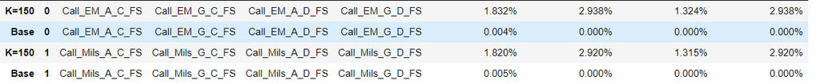

(ii) For Fixed Strike variants, Puts accuracy improved with convergence between schemes.

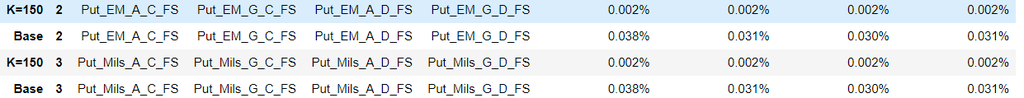

(iii) There were no observable change in Fixed Price Variants (across call/put and schemes) after parameter change. This is logical as the strike is replaced with the averaged price.

```python
# Relative Diff to GBM Price,% with K =70
#Strike 70 was used instead of 50 as relative difference of two near zero would caused error.
#Higher Volatility would be required to fix this issue but would render comparison with Base Case obsolete.
t6 =test_sim(0.05, 0.2 ,1 , 252, 5000, 70)
t6=t6.iloc[[0,1,2,3,4,5,6,7]]
t6 = t6.droplevel(2, axis=1).droplevel(1, axis=1).drop(['Ins Code'], axis=1)
tmp6 = pd.concat([t6, t1], keys=['K=70', 'Base'])
tmp6.iloc[[0,8,1,9,2,10,3,11,4,12,5,13,6,14,7,15]]
```

|  |  | Ins Name | Ins Name | Ins Name | Ins Name | Rel Diff to GBM Price, % | Rel Diff to GBM Price, % | Rel Diff to GBM Price, % | Rel Diff to GBM Price, % |
| --- | --- | --- | --- | --- | --- | --- | --- | --- | --- |
| K=70 | 0 | Call_EM_A_C_FS | Call_EM_G_C_FS | Call_EM_A_D_FS | Call_EM_G_D_FS | 0.003% | 0.003% | 0.003% | 0.003% |
| Base | 0 | Call_EM_A_C_FS | Call_EM_G_C_FS | Call_EM_A_D_FS | Call_EM_G_D_FS | 0.004% | 0.000% | 0.000% | 0.000% |
| K=70 | 1 | Call_Mils_A_C_FS | Call_Mils_G_C_FS | Call_Mils_A_D_FS | Call_Mils_G_D_FS | 0.003% | 0.003% | 0.003% | 0.003% |
| Base | 1 | Call_Mils_A_C_FS | Call_Mils_G_C_FS | Call_Mils_A_D_FS | Call_Mils_G_D_FS | 0.005% | 0.000% | 0.000% | 0.000% |
| K=70 | 2 | Put_EM_A_C_FS | Put_EM_G_C_FS | Put_EM_A_D_FS | Put_EM_G_D_FS | 3.964% | 2.509% | 2.136% | 2.509% |
| Base | 2 | Put_EM_A_C_FS | Put_EM_G_C_FS | Put_EM_A_D_FS | Put_EM_G_D_FS | 0.038% | 0.031% | 0.030% | 0.031% |
| K=70 | 3 | Put_Mils_A_C_FS | Put_Mils_G_C_FS | Put_Mils_A_D_FS | Put_Mils_G_D_FS | 3.911% | 2.458% | 2.107% | 2.458% |
| Base | 3 | Put_Mils_A_C_FS | Put_Mils_G_C_FS | Put_Mils_A_D_FS | Put_Mils_G_D_FS | 0.038% | 0.031% | 0.030% | 0.031% |
| K=70 | 4 | Call_EM_A_C_FP | Call_EM_G_C_FP | Call_EM_A_D_FP | Call_EM_G_D_FP | 0.021% | 0.018% | 0.019% | 0.018% |
| Base | 4 | Call_EM_A_C_FP | Call_EM_G_C_FP | Call_EM_A_D_FP | Call_EM_G_D_FP | 0.021% | 0.018% | 0.019% | 0.018% |
| K=70 | 5 | Call_Mils_A_C_FP | Call_Mils_G_C_FP | Call_Mils_A_D_FP | Call_Mils_G_D_FP | 0.021% | 0.017% | 0.018% | 0.017% |
| Base | 5 | Call_Mils_A_C_FP | Call_Mils_G_C_FP | Call_Mils_A_D_FP | Call_Mils_G_D_FP | 0.021% | 0.017% | 0.018% | 0.017% |
| K=70 | 6 | Put_EM_A_C_FP | Put_EM_G_C_FP | Put_EM_A_D_FP | Put_EM_G_D_FP | 0.041% | 0.046% | 0.042% | 0.046% |
| Base | 6 | Put_EM_A_C_FP | Put_EM_G_C_FP | Put_EM_A_D_FP | Put_EM_G_D_FP | 0.041% | 0.046% | 0.042% | 0.046% |
| K=70 | 7 | Put_Mils_A_C_FP | Put_Mils_G_C_FP | Put_Mils_A_D_FP | Put_Mils_G_D_FP | 0.040% | 0.045% | 0.041% | 0.045% |
| Base | 7 | Put_Mils_A_C_FP | Put_Mils_G_C_FP | Put_Mils_A_D_FP | Put_Mils_G_D_FP | 0.040% | 0.045% | 0.041% | 0.045% |

**Observation for t6:**

With changing K=100 to K=70:

(i) Huge jump in Fixed Strike Puts, attributed to relative difference of very low option values.

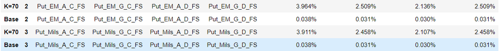

(iii) There were no observable change in Fixed Price Variants (across call/put and schemes) after parameter change. This is logical as the strike is replaced with the averaged price.

```python
# Relative Diff to GBM Price,% with T = 10 with 2520 steps
t7 =test_sim(0.05, 0.2 ,10 , 2520, 5000, 100)
t7=t7.iloc[[0,1,2,3,4,5,6,7]]
t7 = t7.droplevel(2, axis=1).droplevel(1, axis=1).drop(['Ins Code'], axis=1)
tmp7 = pd.concat([t7, t1], keys=['T=10', 'Base'])
tmp7.iloc[[0,8,1,9,2,10,3,11,4,12,5,13,6,14,7,15]]
```

|  |  | Ins Name | Ins Name | Ins Name | Ins Name | Rel Diff to GBM Price, % | Rel Diff to GBM Price, % | Rel Diff to GBM Price, % | Rel Diff to GBM Price, % |
| --- | --- | --- | --- | --- | --- | --- | --- | --- | --- |
| T=10 | 0 | Call_EM_A_C_FS | Call_EM_G_C_FS | Call_EM_A_D_FS | Call_EM_G_D_FS | 0.007% | 0.011% | 0.006% | 0.011% |
| Base | 0 | Call_EM_A_C_FS | Call_EM_G_C_FS | Call_EM_A_D_FS | Call_EM_G_D_FS | 0.004% | 0.000% | 0.000% | 0.000% |
| T=10 | 1 | Call_Mils_A_C_FS | Call_Mils_G_C_FS | Call_Mils_A_D_FS | Call_Mils_G_D_FS | 0.007% | 0.011% | 0.006% | 0.011% |
| Base | 1 | Call_Mils_A_C_FS | Call_Mils_G_C_FS | Call_Mils_A_D_FS | Call_Mils_G_D_FS | 0.005% | 0.000% | 0.000% | 0.000% |
| T=10 | 2 | Put_EM_A_C_FS | Put_EM_G_C_FS | Put_EM_A_D_FS | Put_EM_G_D_FS | 0.010% | 0.004% | 0.014% | 0.004% |
| Base | 2 | Put_EM_A_C_FS | Put_EM_G_C_FS | Put_EM_A_D_FS | Put_EM_G_D_FS | 0.038% | 0.031% | 0.030% | 0.031% |
| T=10 | 3 | Put_Mils_A_C_FS | Put_Mils_G_C_FS | Put_Mils_A_D_FS | Put_Mils_G_D_FS | 0.010% | 0.003% | 0.014% | 0.003% |
| Base | 3 | Put_Mils_A_C_FS | Put_Mils_G_C_FS | Put_Mils_A_D_FS | Put_Mils_G_D_FS | 0.038% | 0.031% | 0.030% | 0.031% |
| T=10 | 4 | Call_EM_A_C_FP | Call_EM_G_C_FP | Call_EM_A_D_FP | Call_EM_G_D_FP | 0.006% | 0.002% | 0.006% | 0.002% |
| Base | 4 | Call_EM_A_C_FP | Call_EM_G_C_FP | Call_EM_A_D_FP | Call_EM_G_D_FP | 0.021% | 0.018% | 0.019% | 0.018% |
| T=10 | 5 | Call_Mils_A_C_FP | Call_Mils_G_C_FP | Call_Mils_A_D_FP | Call_Mils_G_D_FP | 0.006% | 0.002% | 0.006% | 0.002% |
| Base | 5 | Call_Mils_A_C_FP | Call_Mils_G_C_FP | Call_Mils_A_D_FP | Call_Mils_G_D_FP | 0.021% | 0.017% | 0.018% | 0.017% |
| T=10 | 6 | Put_EM_A_C_FP | Put_EM_G_C_FP | Put_EM_A_D_FP | Put_EM_G_D_FP | 0.053% | 0.041% | 0.049% | 0.041% |
| Base | 6 | Put_EM_A_C_FP | Put_EM_G_C_FP | Put_EM_A_D_FP | Put_EM_G_D_FP | 0.041% | 0.046% | 0.042% | 0.046% |
| T=10 | 7 | Put_Mils_A_C_FP | Put_Mils_G_C_FP | Put_Mils_A_D_FP | Put_Mils_G_D_FP | 0.052% | 0.041% | 0.049% | 0.041% |
| Base | 7 | Put_Mils_A_C_FP | Put_Mils_G_C_FP | Put_Mils_A_D_FP | Put_Mils_G_D_FP | 0.040% | 0.045% | 0.041% | 0.045% |

**Observation for t7:**

With changing T=1 to T=10:

(i) Fixed Strike Calls accuracy declined slightly.

References: Ahmad, Riaz (2023). Tutorials- Further Numerical Methods & FDM. Retrieved from CQF Learning Portal: https://learn.cqf.com/courses/170/modules/items/2647